# Chicago Covid Data Analysis

Robert Crump

October 21, 2021

[GitHub Repository](https://github.com/rwrcrump/CDPH)

## Executive Summary

The COVID-19 pandemic profoundly impacted the City of Chicago, particularly communities of color on the South and West sides. As of October 20th 2021, COVID-19 has claimed 6024 lives, mostly in majority Black and Hispanic neighborhoods and among people 60 years old or older. This analysis uses City of Chicago Department of Public Health data to generate a high-level overview of pandemic trends and assess the effectiveness of vaccine deployment in preventing death among the most vulnerable populations.

## Data

I retrieved this data from the City of Chicago open data portal[^1]. This dataset contains the rolling average of cases, deaths, and hospitalizations for every seven-day period ending on each date. Every row is a single day corresponding to the end of a seven-day period, and 97 columns comprise various demographic categories. For this analysis, I focus on death counts and rates (per 100,000 people) by age and race.

This dataset treats both age and race as categorical variables. Age variables are divided into brackets: 0-17, 18-29, 30-39, etc. It has been well documented that older adults are most vulnerable to serious illness and death after getting infected with COVID-19. To simplify the analysis, I grouped age brackets into two categories: under 60 and 60 & over.

## Exploratory Data Analysis

Let’s start with a broad overview of total cases, hospitalizations, and deaths over the whole pandemic. The data starts on March 13th, 2020.

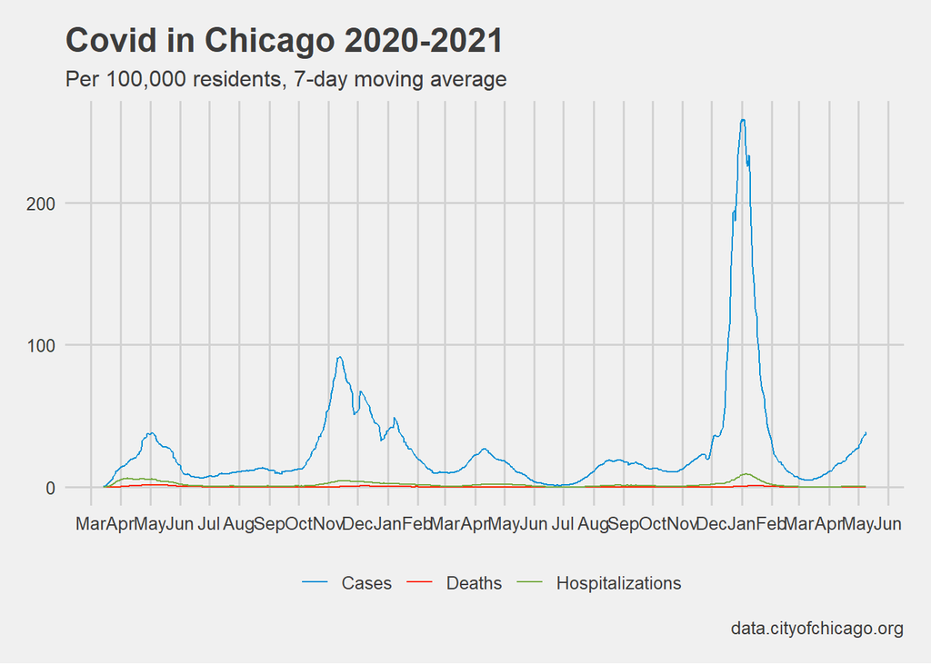

Cases spike dramatically at different times, while hospitalizations and deaths remain relatively more stable. There are few possible inferences to draw from the divergence between the three rates. First, mitigation efforts were effective in preventing most cases from developing into severe illness. Second, it’s possible that cases during the later peaks were concentrated among less vulnerable people. Lastly, we improved somewhat in treatment and behavioral change to reduce exposure to vulnerable populations.

Next, let’s focus in on death rates by race.

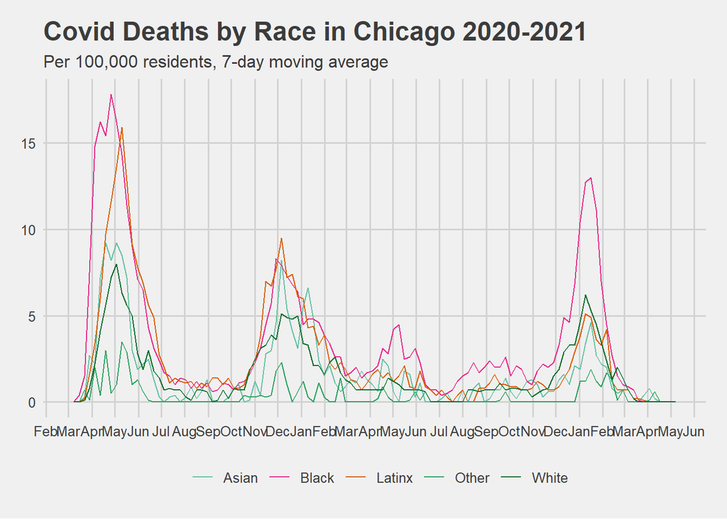

Non-Black and non-Latinx races are shaded green to highlight the racially disproportionate impacts of the pandemic. Although there is some variability over time, the first and second-most covid deaths during the pandemic belong to Black and Latinx racial categories.

Now, let’s examine death rates by age split between two age categories.

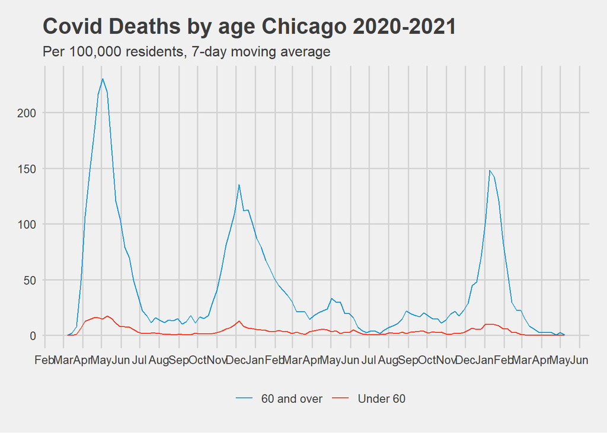

These charts illustrate the leading demographic predictors of death following a COVID-19 infection. Below is a summary table of these findings.

Covid Deaths in Chicago:

|  | Total Deaths | Proportion |
| --- | --- | --- |
| Full Pop. | 6024 | 100% |
| Black | 2443.1 | 41% |
| Latinx | 1951.5 | 32% |
| Over 60 | 4754.7 | 79% |

## Statistical analysis of vaccine efficacy

Near the end of 2020, the City of Chicago began distributing vaccines to frontline healthcare workers. Over the next several months, the City introduced a phased vaccine distribution campaign that prioritized older residents and younger people with co-morbidities[^2].

- Phase 1A: December 15th, 2020
  - Healthcare & longterm residential care workers
- Phase 1B: January 25, 2021
  - 65 years old and older, most essential workers, shelters & prisons
- Phase 1C: March 29, 2021
  - 16-64 years old with co-morbidities, all essential workers
- Phase 2: April 19, 2021
  - All Chicagoans over 16 years old

Phase 1B provides a clear marker in time to assess vaccine efficacy among vulnerable populations. Although it does not match perfectly with age brackets in our data, it’s close enough to evaluate the impact of vaccination on the 60 and over population, including Black and Latinx folks who may fall into the same age category. Since distribution takes time and immunization is delayed about two weeks after treatment, we should consider an appropriate range of time around vaccine deployment to properly measure population health trends. To capture *pre* and *post* trends before and after Jan 25, I subsetted the data to include only death counts that fall within December 1, 2020 and March 31st, 2021.

**Phase 1B (Dec. 1, 2020 - Mar. 31, 2021) Deaths by Demographic**

|  | *Dependent variable:* |  |  |
| --- | --- | --- | --- |
|  | Black | Latinx | Over 60 |
|  | (1) | (2) | (3) |
| Av. Deaths per Day | -0.07*** | -0.08*** | -0.18*** |
|  | (0.002) | (0.002) | (0.003) |
| Constant | 1,295.75*** | 1,492.55*** | 3,391.73*** |
|  | (35.40) | (45.42) | (64.97) |
| Observations | 121 | 121 | 121 |
| R<sup>2</sup> | 0.92 | 0.90 | 0.96 |
| Adjusted R<sup>2</sup> | 0.92 | 0.90 | 0.96 |
| Residual Std. Error (df = 119) | 0.73 | 0.94 | 1.34 |
| *Note:* | p<0.1; p<0.05; p<0.01 |  |  |
|  | dataset::CDPH |  |  |
|  | lm() univariate |  |  |

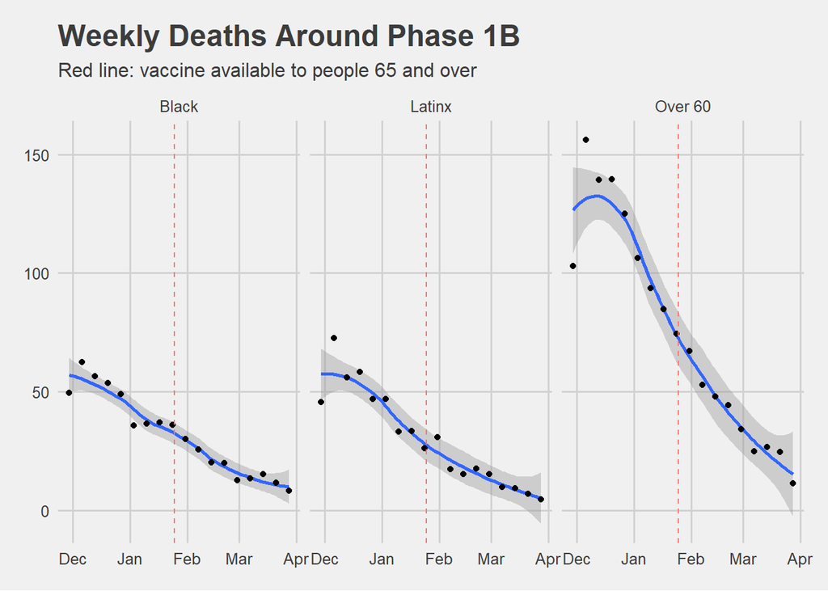

It’s also worth noting that a major spike in cases, hospitalizations, and deaths occurred around the holiday season, so the downward slope following that period may be at least partially attributable to trends stabilizing after a local peak.

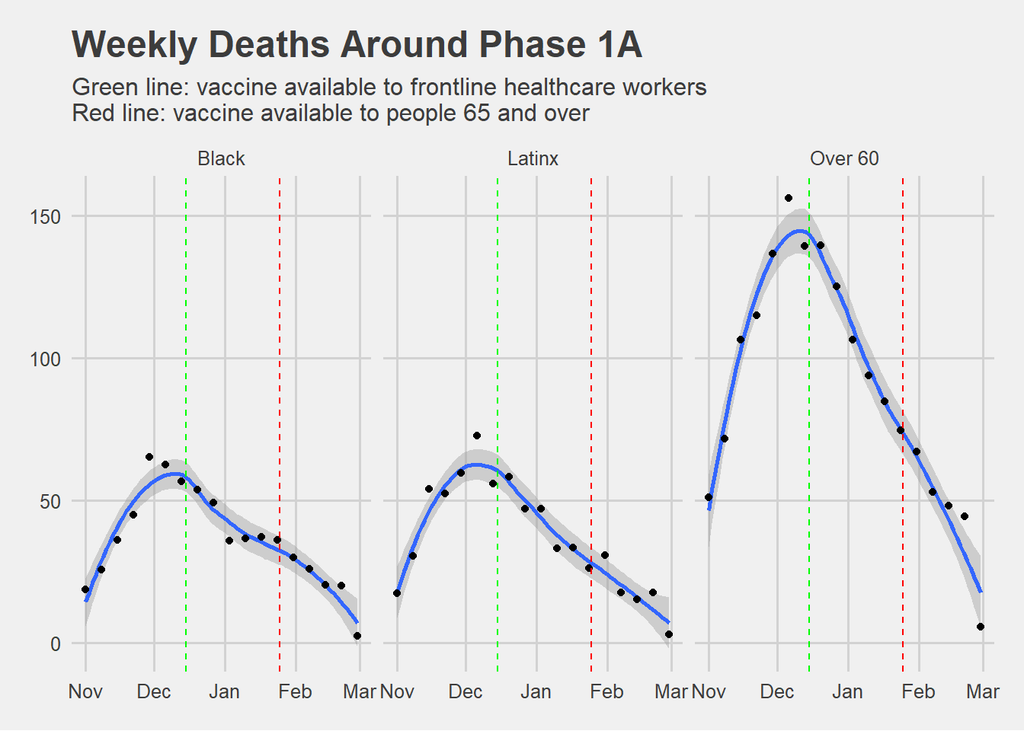

By pushing back our timeframe by one month (November 1, 2020 - February 28, 2021), we can see a very clear shift in covid deaths among each demographic population subset just before the vaccine was deployed to medical staff. I think there are a few key takeaways evidenced by this chart. First, the downward trend started before vaccines came online. We see a peak between Thanksgiving and Christmas, then a steep decline heading into 2021. Infection and death rates spiked when people gathered for Thanksgiving, but started to drop afterwards. Second, once vaccines were introduced into the population through nurses and other healthcare professionals, the downward trend continued instead of spiking again after Christmas.

There is another potentially disturbing implication in this data, although I cannot comment on its validity without more research and collaboration. The demographics shown in these charts don’t include an occupational subset for the healthcare industry. But, deploying vaccines to them dramatically decreased covid deaths among the most vulnerable populations. One potential way to interpret this data is that frontline healthcare workers are major disease vectors themselves. The first two key takeaways suggest potentially cogent counterarguments. Factors outside of vaccination (like policy and behavior) impact transmission rates, which is why we see a huge peak right before lockdowns went into effect in Spring 2020. Also, introducing vaccinations into the general population at any level may have had a similar effect. Once a virus encounters an inoculated person, it is less likely to spread to another person breaking the chain of transmission within a population.

### Regression Discontinuity Design

$$Y_i = \alpha + \tau V_i(binary) + \epsilon_i$$
Where $i$ represents a given day during Phase 1A, the dependent variable $Y$ represents deaths counts for a demographic subset, $\alpha$ represents the constant, $\tau$ represents the magnitude effect of vaccine availability $V(binary)$ in the *pre* and *post* periods, and $\epsilon$ represents the error term.

**Phase 1A (Nov. 1, 2020 - Feb. 28, 2021) Regression Discontinuity Design**

|  | *Dependent variable:* |  |  |
| --- | --- | --- | --- |
|  | Black | Latinx | Over 60 |
|  | (1) | (2) | (3) |
| Vax Available (Binary) | -1.16*** | -2.12*** | -3.27*** |
|  | (0.39) | (0.45) | (0.94) |
| Constant | 6.18*** | 6.91*** | 15.52*** |
|  | (0.31) | (0.35) | (0.74) |
| Observations | 120 | 120 | 120 |
| R<sup>2</sup> | 0.07 | 0.16 | 0.09 |
| Adjusted R<sup>2</sup> | 0.06 | 0.15 | 0.09 |
| Residual Std. Error (df = 118) | 2.06 | 2.37 | 4.97 |
| *Note:* | p<0.1; p<0.05; p<0.01 |  |  |
|  | dataset::CDPH |  |  |
|  | rdd() univariate |  |  |

This dataset limits the ability to analyze covariates such as the interaction between race and age. Since these data are death counts across demographic categories, there is significant overlap between people over 60 and people who are Black or Latinx. At best, we can identify proportional outcomes for different demographic groups. Without individual level data, estimating the causal effects of belonging to an age *and* race category would not be a valid statistical measure because the outcome variable $Y_{over 60}$ and the predictor variable $X_{race}$ are not independent of each other.

[^1]: https://data.cityofchicago.org/Health-Human-Services/COVID-19-Daily-Rolling-Average-Case-Death-and-Hosp/e68t-c7fv
[^2]: https://www.chicago.gov/city/en/sites/covid19-vaccine/home/vaccine-distribution-phases.html